# POLISCI 150B/355B Section 02

Go back to Index

## Program your own lm function

In this section we are going to write our own `lm` function to return the results of bivariate and multivariate regressions. We’ll start by programming the function to compute a bivariate regression, and then make a few tweaks so that it can handle multivariate regressions.

### Step 1: setup your function.

Start by setting up the skeleton of your function, as shown below. First, let’s decide what our input will be. One strategy is to get the user to input two arguments: `y` containing the data for the response variable and `x` containing the data for the explanatory variable (another strategy would have been to have the user provides a dataset and a formula, similar to how you use the real `lm` function).

```r
# ----------------------------- #
# Function: MyLM()
# Usage: lmResult <- MyLM(...)
# Description:
#   TODO: add description.
#
# Parameters:
#   TODO: add description of function parameters.
# ----------------------------- #
MyLM <- function(...) {
    # TODO: implement this function.
    result <- NULL
    return(result)
}
```

Let’s also create a simulated dataset so that we can test our function as we go along:

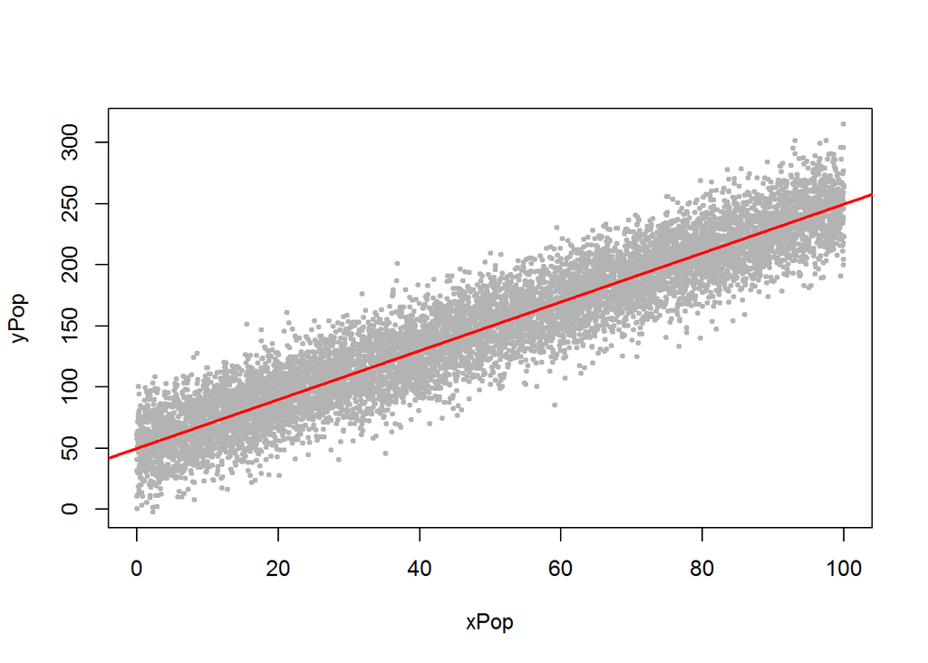

```r
# simulates the population regression function from which we will sample
nObs <- 1e4  #10,000 obs
xPop <- runif(nObs, min=0, max=100) ## Observations from an Uniform distribution
e    <- rnorm(nObs, mean=0, sd=20)  ## Random error with Normal distribution
yPop <- 50 + 2 * xPop + e           ## Formula for the population, not that the slope is known

# plots the population data and regression function.
plot(xPop, yPop, pch=19, col='gray70', cex=0.5)
abline(a=50, b=2, col='red', lwd=2)
```

```r
# takes a sample of 500 from x and y in the population
set.seed(4928)
nSamp <- 500
sampIndices <- sample(1:nObs, nSamp, replace=FALSE)
xSamp <- xPop[sampIndices]
ySamp <- yPop[sampIndices]
# we'll use xSamp and ySamp as our data as we move along.
```

### Step 2: compute coefficients

Next, let’s compute the regression coefficients using the following equations for bivariate regression:

$$\hat \beta_1 = \frac{\sum (x_i - \bar x) (y_i - \bar y)}{\sum (x_i - \bar x)^2}$$
$$\hat \beta_0 = \bar y - \hat \beta_1 \bar x$$

```r
MyLM <- function(x, y) {
    # computes regression coefficients
    beta1 <- cov(x,y) / var(x)
    beta0 <- mean(y) - beta1 * mean(x)

    # returns the result
    result <- NULL
    return(result)
}
```

### Step 3: save coefficients in a vector and return the result

```r
MyLM <- function(x, y) {
    # computes regression coefficients
    beta1 <- cov(x,y) / var(x)
    beta0 <- mean(y) - beta1 * mean(x)

    # returns the result
    result <- c(beta0, beta1)
    names(result) <- c('beta0', 'beta1')
    return(result)
}
```

### Step 4: error-checking

Note that this is a bit tricky beceause we need to make sure to do *list-wise* deletion – i.e. if we remove a particular y observation because it has an `NA` value, then we need to make sure to delete the corresponding x observation (even if it is not `NA`).

*NOTE: there are several other reasons that this function might not work properly – for instance, if `x` or `y` are not numeric or if `x` and `y` are different lengths. The function below does not check for these problems.*

*NOTE: you can use the `stop()` function to report errors to the user.*

```r
MyLM <- function(x, y) {
    # removes any NA values (if applicable) using listwise deletion.
    if (any(is.na(x)) | any(is.na(y))) {
        data <- data.frame(y=y, x=x) # If any condition is true, create a temporary dataframe
        data <- data[complete.cases(data),] # Keep no missing values
        y <- data$y
        x <- data$x
    }

    # computes regression coefficients
    beta1 <- cov(x,y) / var(x)
    beta0 <- mean(y) - beta1 * mean(x)

    # returns the result
    result <- c(beta0, beta1)
    names(result) <- c('beta0', 'beta1')
    return(result)
}
```

### Step 5: testing

Now let’s test out our function ane make sure it works!

```r
# we already have our data in xSamp and ySamp, so we just need to run the regression with this data in lm and in our own function
myCoefs <- MyLM(xSamp, ySamp)
myCoefs
```

```
##    beta0    beta1
## 49.80854  2.01778
```

```r
lmCoefs <- lm(ySamp ~ xSamp)
summary(lmCoefs)
```

```
##
## Call:
## lm(formula = ySamp ~ xSamp)
##
## Residuals:
##    Min     1Q Median     3Q    Max
## -66.45 -13.61   0.73  14.02  63.84
##
## Coefficients:
##             Estimate Std. Error t value Pr(>|t|)
## (Intercept) 49.80854    1.84920   26.93   <2e-16 ***
## xSamp        2.01778    0.03271   61.69   <2e-16 ***
## ---
## Signif. codes:  0 '***' 0.001 '**' 0.01 '*' 0.05 '.' 0.1 ' ' 1
##
## Residual standard error: 20.96 on 498 degrees of freedom
## Multiple R-squared:  0.8843, Adjusted R-squared:  0.884
## F-statistic:  3805 on 1 and 498 DF,  p-value: < 2.2e-16
```

Great!

### Multivariate lm function

Now let’s tweak the function so that it can compute multivariate regressions. First, we now need the user to supply a matrix of explanatory variables (I’ve replaced the `x` argument with `X` to indicate this).

Second, we need to tweak our `NA` removal chunk a little. I have simply replaced the line `data <- data.frame(y=y, x=x)` with `data <- data.frame(y=y, X)` and have replaced `x <- data$x` with `X <- data[,-1]` so that it stores all columns of the dataframe except the first one (which is the response variable).

Third, we need to change how the coefficients are computed. One strategy would be to add lines for beta2, beta3, et cetera using the appropriate equations for multivariate regression. But it is much easier to use linear algebra for this. Specifically, the vector of coefficients for a linear regression can be computed as:

$$\mathbf{\beta} = \mathbf{(X^\prime X)^{-1} X^\prime y}$$

```r
MyLM <- function(X, y) {
    # removes any NA values (if applicable) using listwise deletion.
    if (any(is.na(X)) | any(is.na(y))) {
        data <- data.frame(y=y, X)
        data <- data[complete.cases(data),]
        y <- data$y
        X <- data[,-1]
    }

    # computes regression coefficients
    X <- cbind(1, X)  # adds vector of 1's to dataframe for computing intercept
    X <- as.matrix(X)  # X needs to be a matrix for R to perform matrix computations
    coefs <- solve((t(X) %*% X)) %*% t(X) %*% y
    rownames(coefs) <- c('intercept', paste('beta',1:(ncol(X)-1), sep=""))  # renames coefficients

    return(coefs)
}
```

Now let’s make sure that the function works as intended. We’ll use the `iraqVote` dataset in the `pscl` library, which has a variable `y` that is equal to 1 if a politician voted for the Iraq War and 0 otherwise:

```r
#install.packages('pscl')
library(pscl)
str(iraqVote)
```

```
## 'data.frame':    100 obs. of  6 variables:
##  $ y         : num  1 1 1 1 1 1 1 1 0 1 ...
##  $ state.abb : Factor w/ 51 levels "AK","AL","AR",..: 2 2 1 1 4 4 3 3 5 5 ...
##  $ name      : Factor w/ 102 levels "AKAKA (D HI)",..: 87 88 75 94 63 71 53 68 11 41 ...
##  $ rep       : logi  TRUE TRUE TRUE TRUE TRUE TRUE ...
##  $ state.name: chr  "Alabama" "Alabama" "Alaska" "Alaska" ...
##  $ gorevote  : num  41.6 41.6 27.7 27.7 44.7 ...
```

```r
# computes multivariate regressions
myCoefsMV <- MyLM(iraqVote[,c('rep', 'gorevote')], iraqVote$y)
myCoefsMV
```

```
##                  [,1]
## intercept  1.17445777
## beta1      0.31693261
## beta2     -0.01237552
```

```r
lmCoefsMV <- lm(y ~ rep + gorevote, data=iraqVote)
summary(lmCoefsMV)
```

```
##
## Call:
## lm(formula = y ~ rep + gorevote, data = iraqVote)
##
## Residuals:
##     Min      1Q  Median      3Q     Max
## -0.7654 -0.1533  0.0509  0.2904  0.5707
##
## Coefficients:
##              Estimate Std. Error t value Pr(>|t|)
## (Intercept)  1.174458   0.236256   4.971 2.87e-06 ***
## repTRUE      0.316933   0.080493   3.937 0.000155 ***
## gorevote    -0.012376   0.004715  -2.625 0.010072 *
## ---
## Signif. codes:  0 '***' 0.001 '**' 0.01 '*' 0.05 '.' 0.1 ' ' 1
##
## Residual standard error: 0.3603 on 97 degrees of freedom
## Multiple R-squared:  0.2888, Adjusted R-squared:  0.2742
## F-statistic:  19.7 on 2 and 97 DF,  p-value: 6.617e-08
```

Awesome!

## Interaction terms

So far, we have set up our regression function as:

$$\hat y = \hat \beta_0 + \hat \beta_1 x_1 + \hat \beta_2 x_2$$

But often this simple functional form is problematic, such as when we suspect that there might be *interactions* between our x variables or when there might be non-linear relationships between y and one of our x variables.

In order to examine how the relationship between y and $x_1$ depends on the value of some third variable $x_2$, we can simply include an interaction term in our regression:

$$\hat y = \hat \beta_0 + \hat \beta_1 x_1 + \hat \beta_2 x_2 + \hat \beta_3 (x_1 * x_2)$$

For instance, let y be a continuous variable measuring income and $x_1$ a continuous variable measuring years of education, $x_2$ is a binary variable taking the value of 1 for females and 0 for males. In this case, if we want to measure the marghinal effect of education on income for males:

$$\hat y = \hat \beta_0 + \hat \beta_1 x_1 + \hat \beta_2 * 0 + \hat \beta_3 (x_1 * 0)$$
$$\hat y = \hat \beta_0 + \hat \beta_1 x_1$$

$$\hat y = \hat \beta_0 + \hat \beta_1 x_1 + \hat \beta_2 * 1 + \hat \beta_3 (x_1 * 1)$$
$$\hat y = \hat \beta_0 + \hat \beta_1 x_1 + \hat \beta_2 + \hat \beta_3 x_1$$
$$\hat y = (\hat \beta_0 + \hat \beta_2) + (\hat \beta_1 + \hat \beta_3) x_1$$

As we can see, this model allows for both a different *intercept* and *slope* on education for males versus females.

*NOTE: whenever you include an interaction term beween two variables (e.g. $x_1$ and $x_2$), make sure to also include the “main effects” in the regression. In other words, if you want to examine an interaction effect between $x_1$ and $x_2$, run the regression $y = \beta_0 + \beta_1 x_1 + \beta_2 x_2 + \beta_3 (x_1 * x_2)$ rather than just $y= \beta_0 + \beta_1 (x_1 * x_2)$.*

*NOTE: In the `lm` function in `R`, you can include an interaction between $x_1$ and $x_2$ by either `lm(y ~ x1 * x2, data=data)` (which automatically includes the main effects) or `lm(y ~ x1 + x2 + x1:x2, data=data)`.*

Let’s investigate thinteraction using a sample from a 1994 survey of hourly wages among South African workers:

```r
# loads the data
wd <- getwd()
setwd(wd)
safrica <- read.csv('safrica.csv')
```

[output not shown]

```r
str(safrica)  # Check basic structure
```

[output not shown]

```r
dim(safrica)  # Check dimensions
```

[output not shown]

```r
head(safrica) # Check first rows
```

[output not shown]

```r
# correlations in the data
cor(safrica[,-1])
```

[output not shown]

```r
# side note: why are age and experience so highly correlated?
# A: because experience has been defined as age - educ - 7.

# regresses wage on education, female, and interaction between the two.
lmResult1 <- lm(wage ~ educ * female, data=safrica)
```

[output not shown]

```r
summary(lmResult1)
```

[output not shown]

```r
coefs <- coef(lmResult1) # Store coeffcients for later
```

[output not shown]

```r
# plots the result
# Let's use ggplot
library(ggplot2)
safrica_plot <- ggplot(safrica, aes(educ, wage))  # Mapping
```

[output not shown]

```r
safrica_plot <- safrica_plot + geom_jitter(size=.5, color='gray70')   # First layer with jitter geometry
```

[output not shown]

```r
safrica_plot <- safrica_plot + geom_abline(intercept=coefs[1], slope =coefs[2], color='red', lwd=1)  # Line for males
```

[output not shown]

```r
safrica_plot <- safrica_plot +
                geom_abline(intercept=coefs[1] + coefs[3], slope=coefs[2] + coefs[4], color='blue', lwd=1) # Line for females
```

[output not shown]

```r
safrica_plot <- safrica_plot + xlab('Education') + ylab('Wage')  # Labels
```

[output not shown]

```r
safrica_plot <- safrica_plot + coord_cartesian(ylim =c(0,25), xlim=c(0,10))  # Zoom in for better visualization
```

[output not shown]

```r
safrica_plot <- safrica_plot + geom_text(x=6,y=4, label='Women', color='blue')  # text
```

[output not shown]

```r
safrica_plot <- safrica_plot + geom_text(x=5,y=10, label='Men', color='red')  #
```

[output not shown]

```r
safrica_plot
```

[output not shown]

**NOTE: Most of this tutorial was prepared by Bobbie McDonald for Polisci 150B in 2016. I just made minimal changes.**